# Final Project

Justus Alfaro

April 6, 2025

### 1 Question of interest

What is the relationship between time from diagnosis to treatment and overall survival time in patients with invasive ductal carcinoma (IDC)?

### 2 Data and EDA

This analysis uses the SEER database, a cancer registry maintained by the NIH that collects detailed, individual information on cancer diagnosis, treatment, and follow up. Although not a national cancer registry, SEER collects data from 14 states, which represent approximately 48% of the US population, with records dating back to the 1970s. For the purposes of this study, I restricted the cohort to patients diagnosed between 2005 and 2015 in order to balance a modern cohort while retaining sufficient follow up time (through 2021). In line with survival analysis best practices, I verified that there was not a significant change in treatment efficacy across diagnosis years. The cohort was composed of patients who were below the age of 90 and received treatment. The follow up time began after treatment was started. Since survival time was in months, and time to treatment was in days, the time at risk was constructed as $\text{Time at Risk} = \text{Survival Months} * 30 - \text{Time to Treatmnet}$. A limitation of this approach is that those with a survival time of less than one month would have a negative time at risk. As there were only 123 individuals with this survival time, I decided to exclude them from the cohort. After these selection steps, the cohort was comprised of 51560 individuals.

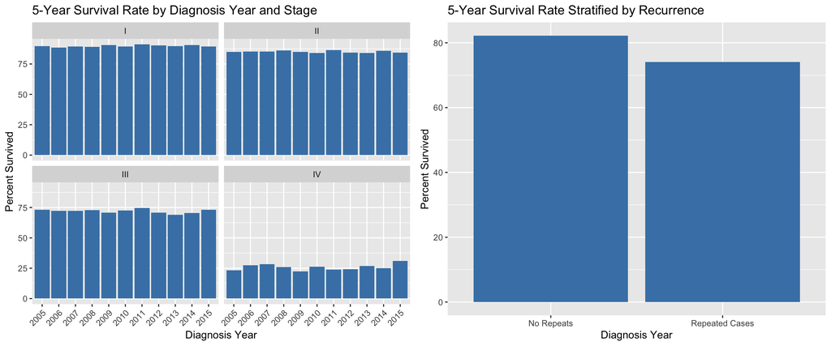

#### 2.1 Racial Breakdown

The cohort’s racial distribution heavily overrepresents white patients. While the majority of the US population white, every other racial group has a significantly lower percent representation than would be expected if the data collection were unbiased. For example, Hispanic patients comprise only 9.1% of the sample, despite accounting for 19.5% of the US population. This suggests a bias in the registry, possibly due to reduced access to treatment for racial minorities. Due to this, the generalizability of these findings is limited.

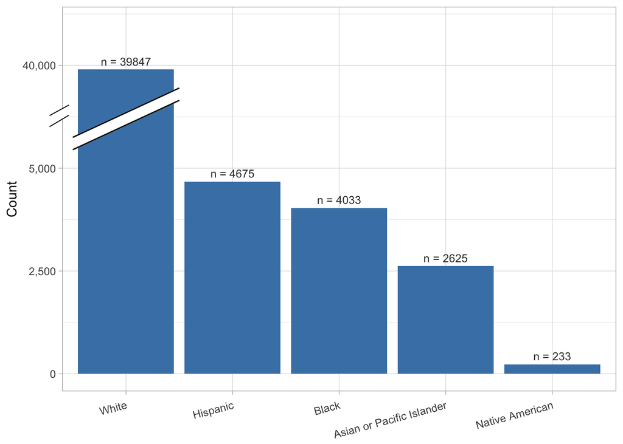

| Race | US Population Percent | Sample Population Percent |
| --- | --- | --- |
| White | 58.4 | 77.3 |
| Hispanic | 19.5 | 9.1 |
| Black | 13.7 | 7.8 |
| Asian or Pacific Islander | 6.7 | 5.1 |
| Native American | 1.3 | 0.5 |

#### 2.2 Time to Treatment EDA

To explore the effect of confounders on my question of interest, I made Kaplan Meier curves which were stratified by potential confounders. Since it is easiest to compare two curves, I split time to treatment into a factor variable, with “long” and “short” groups using 30 days as the cutoff. However, this threshold gave counterintuitive results, as longer treatment delays seemingly indicated improved survival. However, this finding could be due to confounding, as disease severity or treatment type could effect survival time and time to treatment.

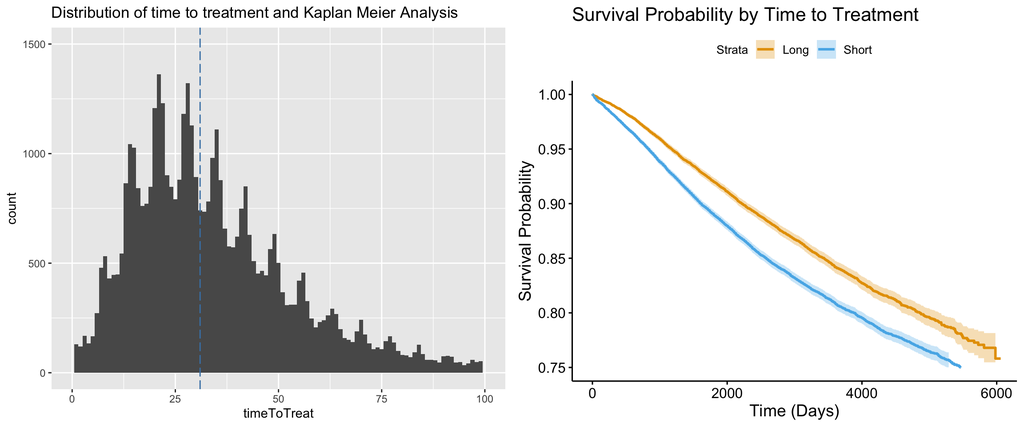

##### Overall

[figure not shown]

##### Stage I

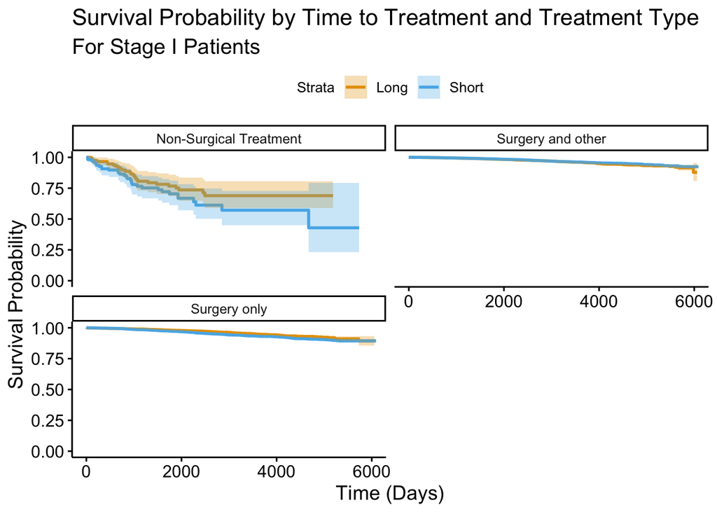

##### Stage II

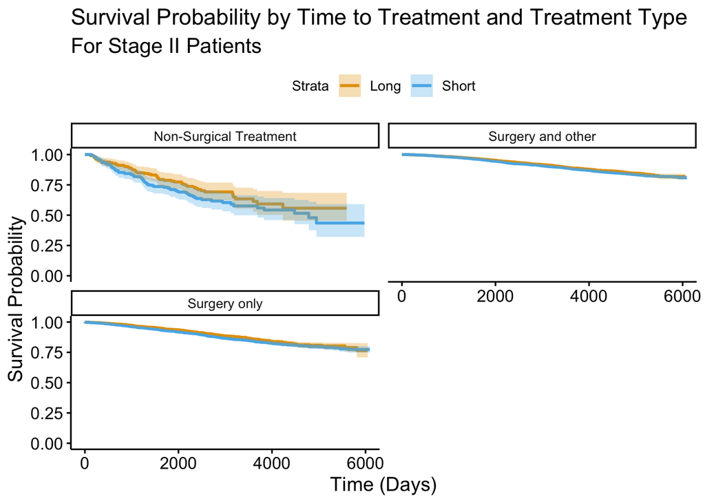

##### Stage III

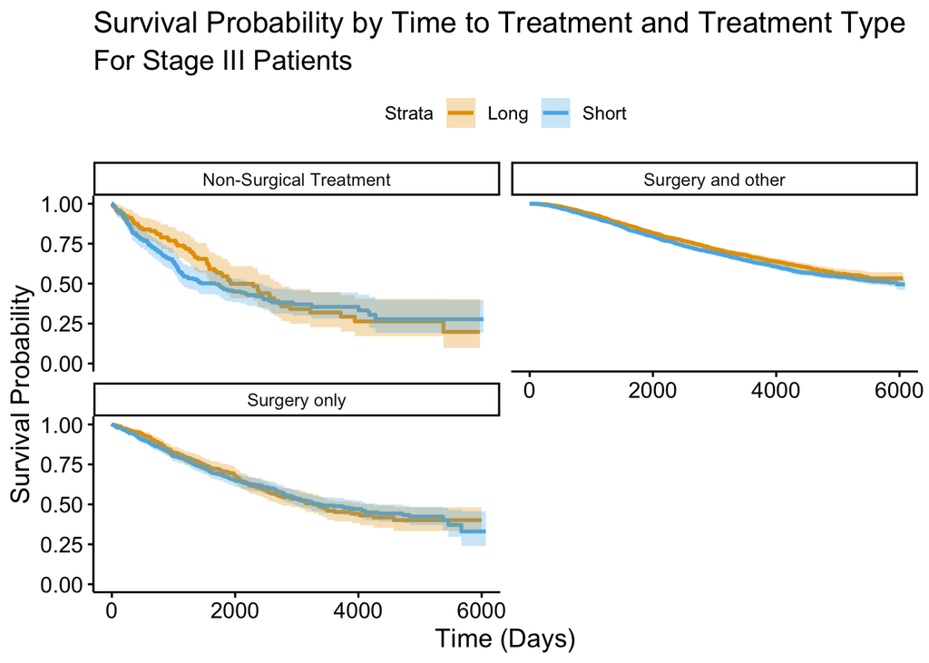

##### Stage IV

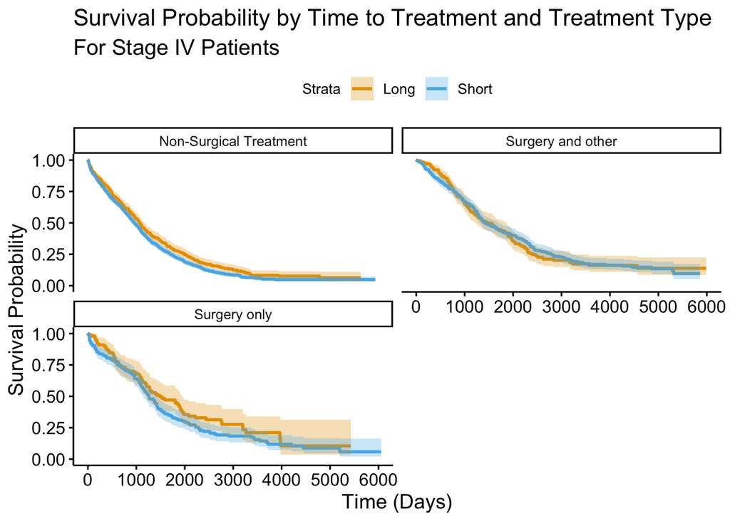

Though I stratified the time to treatment for visualization, I do plan to use a continuous variable in my analysis. In order to explore the continuous relationship, I also plotted a smoothed line representing the survival time as a function of time to treatment (excluding censored cases), which showed no major trends. Though significantly longer delays appear to have worse survival outcomes, this could be due to smaller sample sizes in the tail of the distribution.

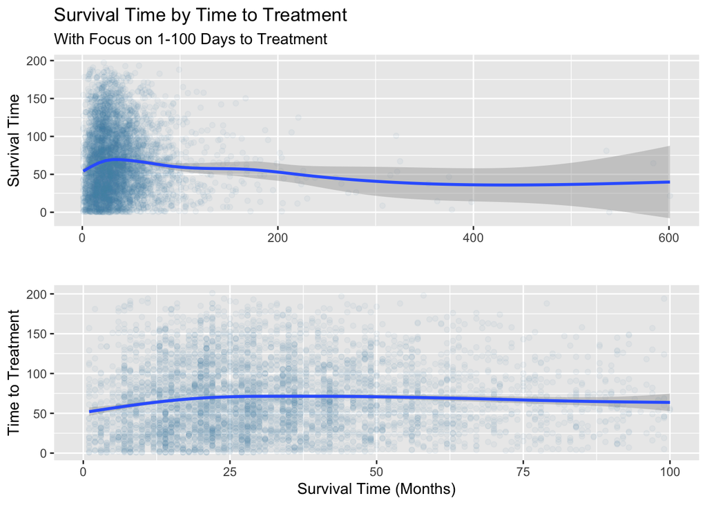

### 3 Analysis Summary

#### 3.1 Variables of interest

- **Outcome variable: Survival Time**
- **Primary predictor variable: Time between diagnosis and treatment**
- **Possible confounders: Age, Stage, Treatment Type, Cancer Recurrence**
- **Potential effect modifiers: Stage at Diagnosis Against Age**

#### 3.2 Directed acyclic graph (DAG)

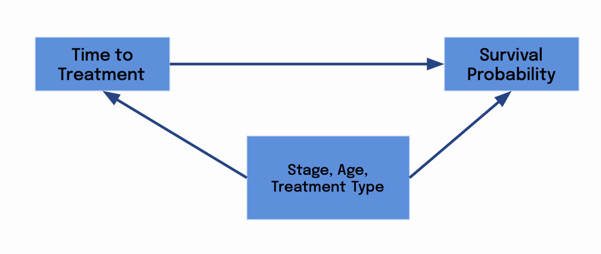

#### 3.3 Statistical analysis plan

In doing this statistical analysis, I played around with including various variables that my EDA (not pictured above) flagged as potentially interesting. These included marriage status, race, and whether this was a repeated diagnosis. My primary criteria was to utilize p-values and AIC scores in order to determine what model had the best fit. Through this, I excluded multiple variables, including county income, level of urbanization, and race.

### 4 Statistical Analysis

#### 4.1 Model Summary

| Term | No Interaction Hazard Ratio | No Interaction 95% Confidence Interval | No Interaction P-value | Interaction Hazard Ratio | Interaction 95% Confidence Interval | Interaction P-value |
| --- | --- | --- | --- | --- | --- | --- |
| Time to Treatment | 1.00 | (1, 1) | 0.38 | 1.00 | (1, 1) | 0.33 |
| Stage II | 2.70 | (2.51, 2.91) | 0.00 | 2.84 | (2.62, 3.08) | 0.00 |
| Stage III | 10.24 | (9.51, 11.02) | 0.00 | 10.82 | (9.99, 11.71) | 0.00 |
| Stage IV | 29.66 | (26.75, 32.88) | 0.00 | 32.10 | (28.87, 35.69) | 0.00 |
| Stage UNK | 5.37 | (4.73, 6.09) | 0.00 | 5.69 | (4.98, 6.51) | 0.00 |
| Age | 1.03 | (1.03, 1.03) | 0.00 | 1.04 | (1.04, 1.05) | 0.00 |
| Surgery only | 0.47 | (0.43, 0.52) | 0.00 | 0.48 | (0.43, 0.52) | 0.00 |
| Surgery and other | 0.39 | (0.36, 0.43) | 0.00 | 0.40 | (0.36, 0.43) | 0.00 |
| Repeated Cases | 1.54 | (1.36, 1.73) | 0.00 | 1.49 | (1.31, 1.68) | 0.00 |
| Stage II : Age | — | — | — | 0.99 | (0.98, 0.99) | 0.00 |
| Stage III : Age | — | — | — | 0.99 | (0.98, 0.99) | 0.00 |
| Stage IV : Age | — | — | — | 0.97 | (0.97, 0.98) | 0.00 |
| Stage UNK : Age | — | — | — | 0.99 | (0.98, 1) | 0.01 |

#### 4.2 Non-interaction Model

The Cox model found essentially no association between time to treatment and hazard of death (HR = 1, 95% CI: (1, 1)). Given our preliminary analysis, this finding is not surprising. In contrast, every confounding variable had significant associations.

Regarding treatment type, patients receiving surgery alone (HR = 0.47, 95% CI: (0.43, 0.52)) or with another treatment (HR = 0.39, 95% CI: (0.36, 0.43)) had much lower hazard of death than those who received non-surgical treatment (baseline). The model also found that patients with repeated diagnoses had a significantly higher hazard (HR = 1.54, 95% CI: (1.36, 1.73)).

#### 4.3 Interaction Model

In the interaction model, I sought to compare how the effect of advanced cancer stages varied by patient age. The age variable was centered around the median age (64) of the study population. Thus, for individuals age 64, the hazard of death with stage IV is32.1 times higher than those with stage I cancer. Surprisingly, the model found that the effect of stage IV cancer weakened by approximately 2.5% per year of age (95% CI: (0.97, 0.98)) above or below the median.

### 5 Validating Assumptions

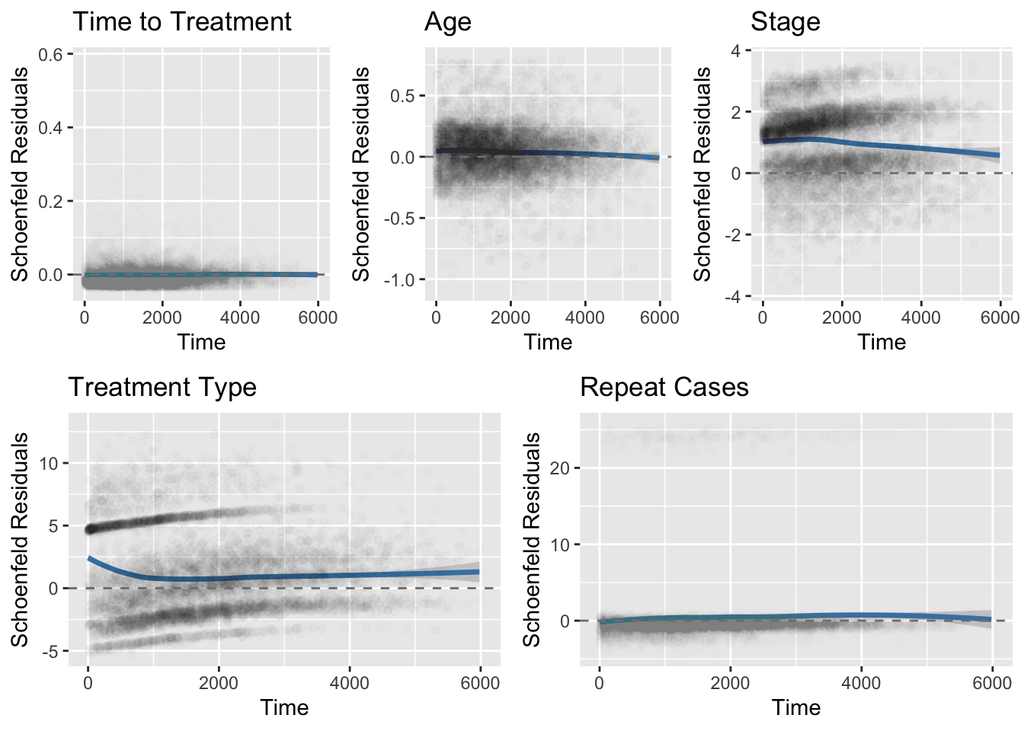

### 6 Limitations

Due to the nature of this dataset, many of the demographic variables were unreliable. Income was only available at the county level, which may not necessarily reflect the true income of an individual. Although race is usually a proxy for income and access, the underrepresentation of minorities made it an unreliable variable. Due to these limitations, any demographic variables included in the model would not have been generalizable outside this cohort. Furthermore, the bias may have contributed to the lack of statistical significance in my initial models.

The other major limitation of this analysis comes from the structure of the study. Since the follow up began at the initiation of treatment, individuals who had a longer time to treatment necessarily survived long enough to receive treatment, which potentially introduced survivorship bias and may have confounded the results.

### 7 Cox Proportional Hazards Model

#### 7.1 Basic Structure

Let $X_i = (X_{i1}, \dots, X_{ip})$ be the realized covariates for subject $i$.

The model is defined by:

$$\begin{aligned}
\lambda(t \mid X_i) &= \lambda_0(t) \cdot \exp(\beta_1 X_{i1} +
\dots + \beta_p X_{ip}) \\
&= \lambda_0(t) \cdot \exp(\beta \cdot X_i)
\end{aligned}$$

Where $\lambda(t \mid X_i)$ is the hazard function of individual $i$ at time $t$, and $\lambda_0$ is a baseline, unknown hazard function.

For two individuals $i$ and $j$, the ratio of their hazards is:

$$\frac{\lambda(t \mid X_i)}{\lambda(t \mid X_j)} =
\frac{\exp(\beta_1 X_{i1} + \dots + \beta_p X_{ip})}{\exp(\beta_1 X_{j1}
+ \dots + \beta_p X_{jp})}$$

Note that $\lambda_0(t)$ cancels out, so the hazard ratio is time-invariant.

Now consider a model with only one covariate, where $X_{i, \text{stageIV}} = X_{j, \text{stageIV}} + 1$:

$$\begin{aligned}
\text{HR} &=
\frac{\exp(\beta_1 X_{i1})}{\exp(\beta_1 X_{j1})} \\
&= \exp\left[\beta_1 (X_{i1} - X_{j1})\right] \\
&= \exp(\beta)
\end{aligned}$$

Thus, the hazard ratio between these two individuals can be represented by $\exp(\beta)$.

#### 7.2 Interaction

Assuming all covariates except the interaction term are baseline:

$$\text{HR} = \frac{
\exp(\beta_{\text{StageIV}} X_{\text{StageIV}} + \beta_{\text{Age}}
X_{\text{Age}} + \beta_{\text{Interaction}} X_{\text{StageIV}}
X_{\text{Age}})
}{
\exp(\beta_{\text{StageIV}} X_{\text{StageIV}} + \beta_{\text{Age}}
X_{\text{Age}} + \beta_{\text{Interaction}} X_{\text{StageIV}}
X_{\text{Age}})
}$$

Now assume same age for both individuals:

$$\begin{aligned}
\text{HR} &=
\frac{
\exp(\beta_{\text{StageIV}} X_{\text{StageIV}} +
\beta_{\text{Interaction}} X_{\text{StageIV}} X_{\text{Age}})
}{
\exp(\beta_{\text{StageIV}} X_{\text{StageIV}} +
\beta_{\text{Interaction}} X_{\text{StageIV}} X_{\text{Age}})
} \\
&= \exp\left[\beta_{\text{StageIV}} (X_i - X_j)\right] \cdot
\exp\left[\beta_{\text{Interaction}} X_{\text{Age}} (X_i - X_j)\right]
\end{aligned}$$

If $X_i = X_j + 1$, then:

$$\text{HR} = \exp(\beta_{\text{StageIV}}) \cdot
\exp(\beta_{\text{Interaction}} \cdot X_{\text{Age}})$$

Thus, the interaction term multiplicatively modifies the effect of Stage IV with respect to age.